# Uber_Pickups_Analysis

### Uber Pickups Analysis Quiz

The question set is based on the August dataset, `uber-raw-data-aug14.csv`.

#### Keeping the dataset ready before questions

```python
import pandas as pd

df = pd.read_csv(r'C:\Users\hp\Downloads\July 24 Uber\Quiz/uber-raw-data-aug14.csv') # change this

df.head()
```

|  | Date/Time | Lat | Lon | Base |
| --- | --- | --- | --- | --- |
| 0 | 8/1/2014 0:03:00 | 40.7366 | -73.9906 | B02512 |
| 1 | 8/1/2014 0:09:00 | 40.7260 | -73.9918 | B02512 |
| 2 | 8/1/2014 0:12:00 | 40.7209 | -74.0507 | B02512 |
| 3 | 8/1/2014 0:12:00 | 40.7387 | -73.9856 | B02512 |
| 4 | 8/1/2014 0:12:00 | 40.7323 | -74.0077 | B02512 |

```python
df.dtypes #-> DateTime type is object we need to convert into datatime format using pd.to_datetime(df['Date/Time'])
```

```
Date/Time     object
Lat          float64
Lon          float64
Base          object
dtype: object
```

#### Q1. On what date did we see the most number of Uber pickups?

**Skill Test:** Grouping & Counting

```python
# Convert the 'Date/Time' column to datetime format

df['Date/Time']=pd.to_datetime(df['Date/Time'])
```

```python
df.dtypes
```

```
Date/Time    datetime64[ns]
Lat                 float64
Lon                 float64
Base                 object
dtype: object
```

```python
df['Date/Time'].dt.date
```

```
0         2014-08-01
1         2014-08-01
2         2014-08-01
3         2014-08-01
4         2014-08-01
             ...
829270    2014-08-31
829271    2014-08-31
829272    2014-08-31
829273    2014-08-31
829274    2014-08-31
Name: Date/Time, Length: 829275, dtype: object
```

```python
# Group by date and count the number of pickups

pickup = df.groupby(df['Date/Time'].dt.date).count()
pickup.head()
```

| Date/Time | Date/Time | Lat | Lon | Base |
| --- | --- | --- | --- | --- |
| 2014-08-01 | 32353 | 32353 | 32353 | 32353 |
| 2014-08-02 | 28678 | 28678 | 28678 | 28678 |
| 2014-08-03 | 23146 | 23146 | 23146 | 23146 |
| 2014-08-04 | 24952 | 24952 | 24952 | 24952 |
| 2014-08-05 | 28094 | 28094 | 28094 | 28094 |

```python
# Find the date with highest number of pickups

highest = pickup.sort_values(by ='Lat',ascending=False)
highest.head(2)
```

| Date/Time | Date/Time | Lat | Lon | Base |
| --- | --- | --- | --- | --- |
| 2014-08-07 | 32759 | 32759 | 32759 | 32759 |
| 2014-08-01 | 32353 | 32353 | 32353 | 32353 |

```python
highest.index[0]
print("Highest number of pickups - ",highest.index[0])
```

```
Highest number of pickups -  2014-08-07
```

#### Q.2 How many Uber pickups were made on the date with the highest number of pickups?

**Skill Test:** Indexing and filtering

```python
# Filter the DataFrame to include only the rows for the date with the highest number of pickups

pickup_highest_date = df[df['Date/Time'].dt.date  == highest.index[0] ]
pickup_highest_date.shape
```

```
(32759, 4)
```

```python
# Get the count of pickups on the highest date

print("No. of pickups - ", pickup_highest_date.shape[0])
```

```
No. of pickups -  32759
```

#### Q.3 How many unique TLC base companies are affiliated with the Uber pickups in the dataset?

**Skill Test:** Counting unique values

```python
# Count the number of unique TLC base companies

unique_company = df['Base'].nunique()
print("No of unique companies affiliated with Uber -",unique_company)
```

```
No of unique companies affiliated with Uber - 5
```

#### Q.4 Which TLC base company had the highest number of pickups?

**Skill Test:** Grouping, counting, and finding the maximum

```python
# Group by TLC base company and count the number of pickups

company_with__pickups  = df.groupby(df['Base']).count()
company_with__pickups.head()
```

| Base | Date/Time | Lat | Lon |
| --- | --- | --- | --- |
| B02512 | 31472 | 31472 | 31472 |
| B02598 | 220129 | 220129 | 220129 |
| B02617 | 355803 | 355803 | 355803 |
| B02682 | 173280 | 173280 | 173280 |
| B02764 | 48591 | 48591 | 48591 |

```python
# Find the TLC base company with the highest number of pickups

highest_base_company = base_company.sort_values(by ='Lat',ascending=False)
highest_base_company.head(2)
```

[output not shown]

#### Q.5 How many Uber pickups were made at each unique TLC base company?

**Skill Test:** Grouping and counting

```python
# Group by TLC base company and count the number of pickups
print(df['Base'].value_counts())

print('----'*5)

print(df.groupby('Base').size())
```

```
B02617    355803
B02598    220129
B02682    173280
B02764     48591
B02512     31472
Name: Base, dtype: int64
--------------------
Base
B02512     31472
B02598    220129
B02617    355803
B02682    173280
B02764     48591
dtype: int64
```

#### Q.6 Can you determine the busiest time of day for Uber pickups based on the date/time column?

**Skill Test:** Extracting time components, grouping, counting, and finding the maximum

```python
# Extract the hour from the 'Date/Time' column

df['Hour'] = df['Date/Time'].dt.hour
df['Hour'].head()
```

```
0    0
1    0
2    0
3    0
4    0
Name: Hour, dtype: int64
```

```python
# Group by hour and count the number of pickups

df['Hour'].value_counts()
```

```
17    57122
18    55390
16    53481
19    53008
20    51674
21    51354
15    48197
22    46008
14    40644
13    35764
8     34566
7     34064
23    33609
12    32106
11    31778
10    30706
9     30195
6     24907
0     21451
5     16525
1     14471
4     11774
3     10376
2     10105
Name: Hour, dtype: int64
```

```python
# Or

print(df.groupby('Hour').size())
```

```
Hour
0     21451
1     14471
2     10105
3     10376
4     11774
5     16525
6     24907
7     34064
8     34566
9     30195
10    30706
11    31778
12    32106
13    35764
14    40644
15    48197
16    53481
17    57122
18    55390
19    53008
20    51674
21    51354
22    46008
23    33609
dtype: int64
```

```python
# Find the hour with the highest number of pickups

Hour_highest_pickups  = Hour.sort_values(by ='Hour',ascending=False)
Hour_highest_pickups.head()
```

[output not shown]

#### Q.7 Can you create a visualization (e.g., a bar chart or line plot) to represent the number of Uber pickups over time?

**Skill Test:** Data Visualization using Plotting function

```python
import matplotlib.pyplot as plt

# Group by date and count the number of pickups

x=df['Date/Time'].dt.date.value_counts()
```

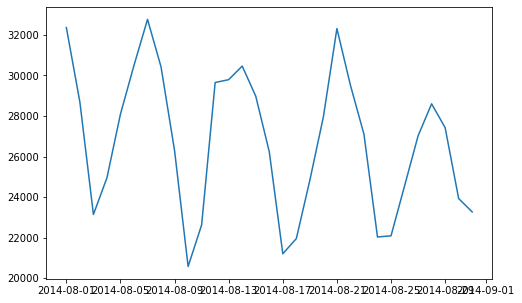

```python
# Create a line plot to visualize the number of pickups over time
x.plot(kind='line',figsize=(8,5))
```

#### Q8. Can you create a scatter plot to visualize the distribution of Uber pickups based on latitude and longitude?

**Skill Test:** Scatter Plot

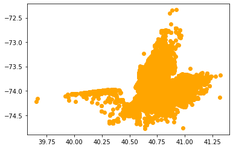

```python
# Create a scatter plot to visualize the distribution of Uber pickups based on latitude and longitude
plt.scatter(df['Lat'],df['Lon'],c='orange', label='Uber_Pickups Data Points')
```

#### Q9. Can you create a bar chart to compare the number of Uber pickups for each TLC base company?

**Skill Test:** Bar Chart

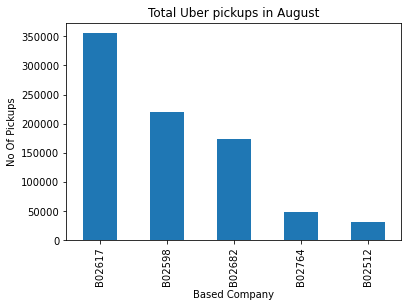

```python
# Create a bar chart to compare the number of Uber pickups for each TLC base company
x=df['Base'].value_counts()
x.plot(kind='bar')
plt.title('Total Uber pickups in August')
plt.xlabel('Based Company')
plt.ylabel('No Of Pickups')
plt.show()
```

#### Q10. Can you create a pie chart to display the percentage distribution of Uber pickups for each day of the week?

**Skill Test:** Pie Chart

```python
# Group by day of the week and count the number of pickups

x=df['Date/Time'].dt.day_name().value_counts()
x
```

```
Friday       148674
Saturday     132225
Thursday     124117
Wednesday    115256
Sunday       110246
Tuesday      107124
Monday        91633
Name: Date/Time, dtype: int64
```

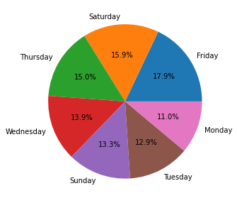

```python
# Create a pie chart to display the percentage distribution of Uber pickups for each day of the week

plt.figure(figsize=(8,5))
plt.pie(x.values,labels=x.index,autopct= '%1.1f%%')
plt.show()
```

[figure not shown]

```python
explode=[0,0.05]
plt.figure(figsize=(8,5))
plt.pie(x.values,labels=x.index,autopct= '%1.1f%%')
labels=['Weekday','Weekend']
plt.legend(labels=labels)
plt.show()
```